# Submission HW1

# ISYE 6501 | Fall 22

- Ashish Dhiman | ashish.dhiman@gatech.edu
- Abhinav Arun | aarun60@gatech.edu
- Anshit Verma | averma373@gatech.edu

*Analysis Notes are marked with Red header: #Analysis

## Question 2.1

### Example 1: Credit Risk Evaluation

Classification models find use cases across a spectrum of Credit Risk functions. A typical example is to a authorize or decline a transaction basis its classification as “risky” or not. Here “risky” implies that the individual might not be able to make the required payments in the future, and therefore transactions made are riskier.

**Objective Function (**$Y$): To classify individual transactions as risky (decline) or not.  
**Predictor Variables (**$X_i$): Some of the key predictor variables given below:

- *Past Delinquency*: Delinquency implies that the individual was unable to keep up on his monthly payments previously and missed on his obligated payments. This is a key marker for credit risk, and past delinquent behavior hints towards potential future risk.
- *Credit Utilization*: Credit Utilization is defined as the ratio of current balance to overall credit limit accorded to the individual. Suppose a individual has a credit line of $10,000 and he already has utilized $ 9k of it. This individual is generally prone to more risk as compared to the individual who only has utilized say $ 2k of his $ 10k line.
- *Current Debt to Income ratio*: This is a measure of Debt to Income Capacity of the individual. In other words, it stacks up the overall debt obligations of the individual across mortgage, auto loan, credit cards etc., against his total income. If a larger part of an individual’s income is directed towards his debt payment, than he/she again might be more susceptible to miss payments in the future and hence is riskier.
- *Amount of Transaction*: This is the dollar amount of the transaction. Intuitively a transaction of $20k is riskier than $5, since even if the individual misses his payment, the hit taken by the firm is restricted to only $5.

### Example 2: Readmission classification in Healthcare analytics

An example of classification problem in Healthcare domain is the classification of whether a patient will get readmitted or not within 30 days of being discharged from a acute hospital setting. Having a good predictive model of the same can help us to curb the healthcare expenditure as the estimated average cost of readmission is more than $10k.

**Objective Function (**$Y$): To classify whether a readmission will happen within 30 days of the Inpatient (Hospital) discharge for a given patient.  
**Predictor Variables (**$X_i$): Some of the key predictor variables given below:

- *Length of stay* : The period for which a patient stays in the Inpatient setting is a key predictor of readmission. A detailed analysis of the same shows that readmission probability is high for both low length of stay (when a patient is discharged earlier than expected without proper treatment) and even when length of stay is larger than a given threshold (because of patient acquiring healthcare associated infections over a prolonged period of stay).
- *Discharge Disposition* : The place where a patient is discharged also a good predictor of whether a person will get readmitted or not within 30 days .For some of the diagnosis categories , if a patient is discharged to home in place of a Post acute care setting , the readmission rate is higher.
- *ED Utilization* : The number of emergency department(ED) visits of a patient within a rolling 1 year is a good predictor of the risk profile of the patient and in turn it is a good predictor of whether a readmission will happen or not.
- *# of changes in medications/procedures* : The number of medication changes is also a good variable for predicting readmission . Higher # of medication changes during hospital stay is correlated with the occurence of a patient being readmitted.

## Question 2.2

### Exploratory Data Analysis (EDA)

#### Read Data and Summary

```r
org_cc_data <- read.table(file = './data 2.2/credit_card_data-headers.txt', sep = "\t", header = TRUE)
dim(org_cc_data)
```

```
## [1] 654  11
```

```r
head(org_cc_data)
```

|  | A1 | A2 | A3 | A8 | A9 | A10 | A11 | A12 | A14 | A15 | R1 |
| --- | --- | --- | --- | --- | --- | --- | --- | --- | --- | --- | --- |
| 1 | 1 | 30.83 | 0.000 | 1.25 | 1 | 0 | 1 | 1 | 202 | 0 | 1 |
| 2 | 0 | 58.67 | 4.460 | 3.04 | 1 | 0 | 6 | 1 | 43 | 560 | 1 |
| 3 | 0 | 24.50 | 0.500 | 1.50 | 1 | 1 | 0 | 1 | 280 | 824 | 1 |
| 4 | 1 | 27.83 | 1.540 | 3.75 | 1 | 0 | 5 | 0 | 100 | 3 | 1 |
| 5 | 1 | 20.17 | 5.625 | 1.71 | 1 | 1 | 0 | 1 | 120 | 0 | 1 |
| 6 | 1 | 32.08 | 4.000 | 2.50 | 1 | 1 | 0 | 0 | 360 | 0 | 1 |

```r
summary(org_cc_data)
```

```
##        A1               A2              A3               A8
##  Min.   :0.0000   Min.   :13.75   Min.   : 0.000   Min.   : 0.000
##  1st Qu.:0.0000   1st Qu.:22.58   1st Qu.: 1.040   1st Qu.: 0.165
##  Median :1.0000   Median :28.46   Median : 2.855   Median : 1.000
##  Mean   :0.6896   Mean   :31.58   Mean   : 4.831   Mean   : 2.242
##  3rd Qu.:1.0000   3rd Qu.:38.25   3rd Qu.: 7.438   3rd Qu.: 2.615
##  Max.   :1.0000   Max.   :80.25   Max.   :28.000   Max.   :28.500
##        A9              A10              A11              A12
##  Min.   :0.0000   Min.   :0.0000   Min.   : 0.000   Min.   :0.0000
##  1st Qu.:0.0000   1st Qu.:0.0000   1st Qu.: 0.000   1st Qu.:0.0000
##  Median :1.0000   Median :1.0000   Median : 0.000   Median :1.0000
##  Mean   :0.5352   Mean   :0.5612   Mean   : 2.498   Mean   :0.5382
##  3rd Qu.:1.0000   3rd Qu.:1.0000   3rd Qu.: 3.000   3rd Qu.:1.0000
##  Max.   :1.0000   Max.   :1.0000   Max.   :67.000   Max.   :1.0000
##       A14               A15               R1
##  Min.   :   0.00   Min.   :     0   Min.   :0.0000
##  1st Qu.:  70.75   1st Qu.:     0   1st Qu.:0.0000
##  Median : 160.00   Median :     5   Median :0.0000
##  Mean   : 180.08   Mean   :  1013   Mean   :0.4526
##  3rd Qu.: 271.00   3rd Qu.:   399   3rd Qu.:1.0000
##  Max.   :2000.00   Max.   :100000   Max.   :1.0000
```

**#Analysis:**

A1,A9,A10,A12 are binary basis min/max values, rest are continuous

For target variable mean is ~45% ==> variable is not grossly imbalanced

```r
org_cc_data1 = org_cc_data
my_groups <- rep("Negative", nrow(org_cc_data))
my_groups[org_cc_data$R > 0] <- "Positive"
org_cc_data1$my_groups <- my_groups

# ggp <- ggplot(org_cc_data1, aes(A3, fill = my_groups)) +  # Seprate density basis label
#   geom_density(alpha=.34) #Make Transperent
# ggp
```

#### Data Distribution and Pairwise Corelation

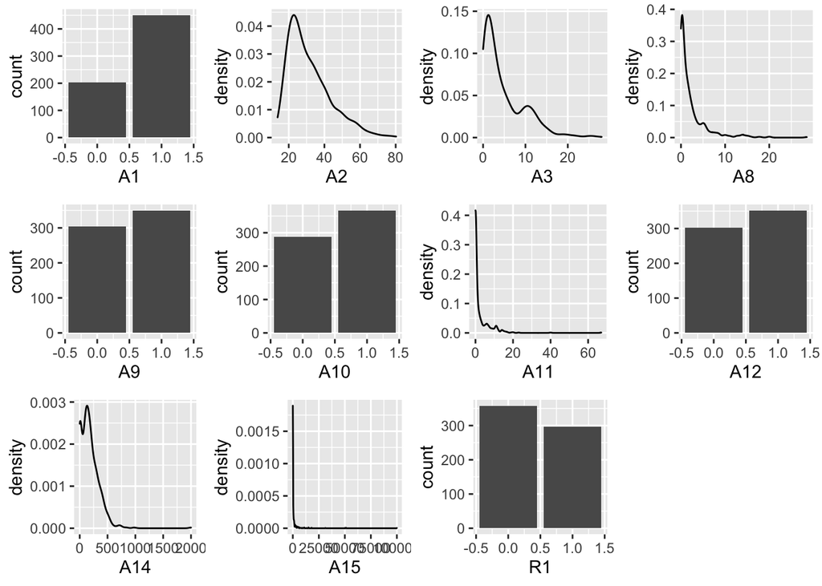

```r
### Data Distribution
my_plots <- lapply(names(org_cc_data), function(var_x){
  p <-
    ggplot(org_cc_data) +
    aes_string(var_x)

  if(var_x %in% list("A1","A9","A10","A12","R1")) {
    p <- p + geom_bar()

  } else {
    p <- p + geom_density()
  }

})

plot_grid(plotlist = my_plots)
```

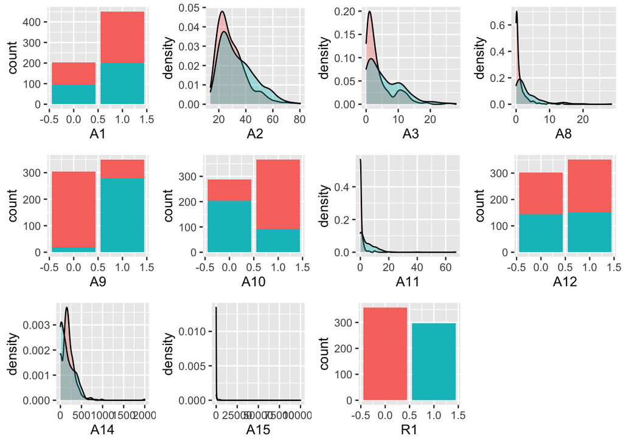

```r
### Seperate Distribution by class labels
my_plots <- lapply(names(org_cc_data1[,1:11]), function(var_x){
  p <-
    ggplot(org_cc_data1[,1:11], aes(var_x, fill = my_groups)) + theme(legend.position="none") +
    aes_string(var_x)

  if(var_x %in% list("A1","A9","A10","A12","R1")) {
    p <- p + geom_bar()

  }
  else {
    p <- p + geom_density(alpha=.34)
  }

})

plot_grid(plotlist = my_plots)
```

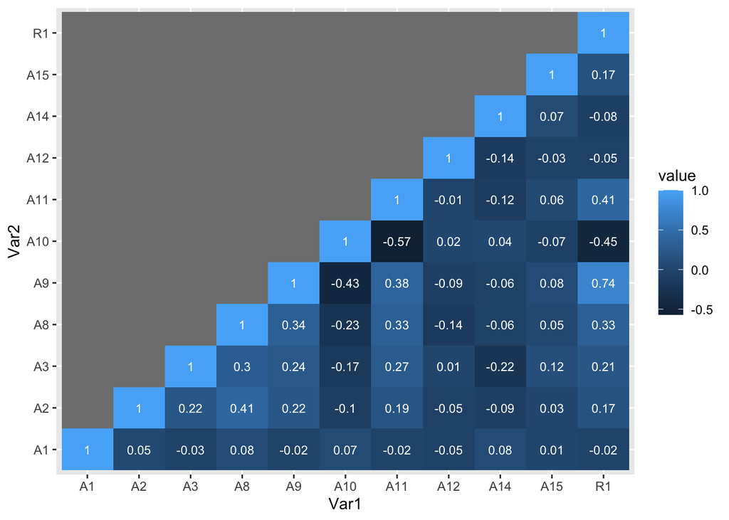

```r
### Corealtion
cormat <- round(cor(org_cc_data),2)
cormat[upper.tri(cormat)] <- NA
melted_cormat <- melt(cormat)
# plotting the correlation heatmap
library(ggplot2)
ggplot(data = melted_cormat, aes(x=Var1, y=Var2,
                                   fill=value)) +
geom_tile() +
geom_text(aes(Var1, Var2, label = value),
          color = "white", size = 3)
```

**#Analysis:**

- Distribution:

  From variables distribution it is apparent that a few variables like A15 are highly skewed.
- Distribution split basis Class:

  Variables like A9 and A10 exhibit disparity in the label distribution, and hence we expect these variables to show up with stronger weights in SVM equation
- Pairwise Corelation:

  If |cor| > 0.3 ==> Significant, then following pairs show high correlation:
  - R1: A8,A9,A10,A11 (We expect these to show up with high weights in SVM eqn.)
  - A11: A8,A9,A10
  - A10: A9
  - A9: A8
  - A8: A2

## Question 2.2 (part 1: kSVM with Linear kernel)

```r
#imports
library(kernlab)
```

```r
library(ggplot2)
```

```r
dim(org_cc_data)
```

```
## [1] 654  11
```

```r
names(org_cc_data)
```

```
##  [1] "A1"  "A2"  "A3"  "A8"  "A9"  "A10" "A11" "A12" "A14" "A15" "R1"
```

### v0: Vanilla Model and Accuracy function

```r
model_v0 = ksvm(x=as.matrix(org_cc_data[,1:10]), y=org_cc_data[,11], scaled =TRUE, type = "C-svc",kernel = "vanilladot", C = 10)
### Accuracy function: Overall and in each class
acc_func <- function(model) {
   pred_all <- predict(model,org_cc_data[,1:10])
   print (paste("Overall Acc:", round(sum(pred_all == org_cc_data[,11]) * 100 / nrow(org_cc_data),4)))

   pred_1 <- predict(model,org_cc_data[org_cc_data$R1 == 1,1:10])
   print (paste("Acc in 1's:", round(sum(pred_1 == org_cc_data[org_cc_data$R1 == 1,11]) * 100 / nrow(org_cc_data[org_cc_data$R1 == 1,1:10]),4)))

   pred_0 <- predict(model,org_cc_data[org_cc_data$R1 == 0,1:10])
   print (paste("Acc in 0's:", round(sum(pred_0 == org_cc_data[org_cc_data$R1 == 0,11]) * 100 / nrow(org_cc_data[org_cc_data$R1 == 0,1:10]),4)))
}

acc_func(model_v0)
```

```
## [1] "Overall Acc: 86.3914"
## [1] "Acc in 1's: 94.2568"
## [1] "Acc in 0's: 79.8883"
```

```r
print(paste("#Support Vectors",model_v0@nSV))
```

```
## [1] "#Support Vectors 190"
```

**#Analysis:**

There are 190 support vectors, or roughly 30% of the total data points, which on first instance seems pretty large. It could be though that many points are in a close neighborhood and therefore a significant number of these points lie near the margin lines.

### Model v1: Optimise C

```r
C_values <- c(0.0001,0.001,0.0015,0.002,0.005,0.01,0.03,0.1,0.5,1) #Range identified with hit and trial

for (C_i in C_values) {
  print (paste("For C = ",C_i))
  acc_func(ksvm(x=as.matrix(org_cc_data[,1:10]), y=org_cc_data[,11], scaled =TRUE, type = "C-svc",kernel = "vanilladot", C = C_i))
  print(paste("#Support Vectors",model_v0@nSV))
  print("")
}
```

```
## [1] "For C =  1e-04"
## [1] "Overall Acc: 54.7401"
## [1] "Acc in 1's: 0"
## [1] "Acc in 0's: 100"
## [1] "#Support Vectors 190"
## [1] ""
## [1] "For C =  0.001"
## [1] "Overall Acc: 83.792"
## [1] "Acc in 1's: 73.6486"
## [1] "Acc in 0's: 92.1788"
## [1] "#Support Vectors 190"
## [1] ""
## [1] "For C =  0.0015"
## [1] "Overall Acc: 86.3914"
## [1] "Acc in 1's: 86.4865"
```

[output cut: 45 more lines]

**#Analysis:**

With increasing C, we weight the cost function more towards mis-classification (relative to margin). Therefore intuitively increasing C, should increase Accuracy albeit at the cost of margin. And in the above data points too, similar effect is apparent, as Accuracy first increases and then plateaus.

### Final SVM Model and it’s equation

```r
modelf = ksvm(x=as.matrix(org_cc_data[,1:10]), y=org_cc_data[,11], scaled =TRUE, type = "C-svc",kernel = "vanilladot", C = 0.0015)
acc_func(modelf)
```

```
## [1] "Overall Acc: 86.3914"
## [1] "Acc in 1's: 86.4865"
## [1] "Acc in 0's: 86.3128"
```

The coefficients of SVM decision boundary is expressed as: $W = \sum_{i \in Supoort\ Vectors}(\alpha_i Y_i X_i)$

```r
a <- colSums(modelf@xmatrix[[1]] * modelf@coef[[1]])
a0 <- -modelf@b
sort(a)
```

```
##          A10          A14          A12           A1           A2           A3
## -0.227739624 -0.022222264 -0.005341560 -0.002338189  0.014772779  0.028456317
##          A15           A8          A11           A9
##  0.096388833  0.107513742  0.169625021  0.488038438
```

```r
a0
```

```
## [1] -0.1072752
```

**#Analysis:**

**As expected (from distribution plots) variables A9, A11, A8, A10 show very significant weights in the decision boundary. Similarly variables like A1,A2 have very low weights, and can also be dropped.**

## Question 2.2 (part 2: kSVM with Non Linear kernel)

Non Linear kernels work by transposing the actual data into a higher dimensional space. Here we have tried two kernels, both of which transform data to the infinite dimension space.

1. Radial Basis, and
2. Laplace

### Non Linear models: Radial Basis Kernel

```r
C_values <- c(0.01,1,10,50,100,1000,2000)

for (C_i in C_values) {
  print (paste("For C = ",C_i))
  modeli = ksvm(x=as.matrix(org_cc_data[,1:10]), y=org_cc_data[,11], scaled =TRUE, type = "C-svc",kernel = "rbfdot", C = C_i)
  acc_func(modeli)
  print(modeli@nSV)
}
```

```
## [1] "For C =  0.01"
## [1] "Overall Acc: 56.7278"
## [1] "Acc in 1's: 4.3919"
## [1] "Acc in 0's: 100"
## [1] 593
## [1] "For C =  1"
## [1] "Overall Acc: 87.156"
## [1] "Acc in 1's: 94.2568"
## [1] "Acc in 0's: 81.2849"
## [1] 271
## [1] "For C =  10"
## [1] "Overall Acc: 90.5199"
## [1] "Acc in 1's: 90.8784"
## [1] "Acc in 0's: 90.2235"
## [1] 255
```

[output cut: 20 more lines]

**#Analysis:**

As seen for Linear Kernels, increase in C, increases accuracy while decreasing number of support vectors. Because this is a very complex model, we are able to get very high accuracy on the training data, however we can’t be sure if the same would generalize to unseen data.

### Non Linear models: Laplace Kernel

```r
C_values <- c(0.01,1,10,50,100,1000,2000)

for (C_i in C_values) {
  print (paste("For C = ",C_i))
  modeli = ksvm(x=as.matrix(org_cc_data[,1:10]), y=org_cc_data[,11], scaled =TRUE, type = "C-svc",kernel = "laplacedot", C = C_i)
  acc_func(modeli)
  print(modeli@nSV)
}
```

```
## [1] "For C =  0.01"
## [1] "Overall Acc: 54.7401"
## [1] "Acc in 1's: 0"
## [1] "Acc in 0's: 100"
## [1] 595
## [1] "For C =  1"
## [1] "Overall Acc: 86.3914"
## [1] "Acc in 1's: 94.2568"
## [1] "Acc in 0's: 79.8883"
## [1] 354
## [1] "For C =  10"
## [1] "Overall Acc: 95.4128"
## [1] "Acc in 1's: 95.6081"
## [1] "Acc in 0's: 95.2514"
## [1] 363
```

[output cut: 20 more lines]

**#Analysis:**

Here again we are able to get 100 accuracy (it appears as if it is grossly overfitting), hence we can’t be sure if the same performance would generalize to unseen data.

## Question 2.3 (knn Model)

### Vanilla knn model

We implement vanilla knn model here, with rectangular (standard unweighted) kernel and majority voting (i.e probability threshold >0.5) among neighbors to decide predicted label.

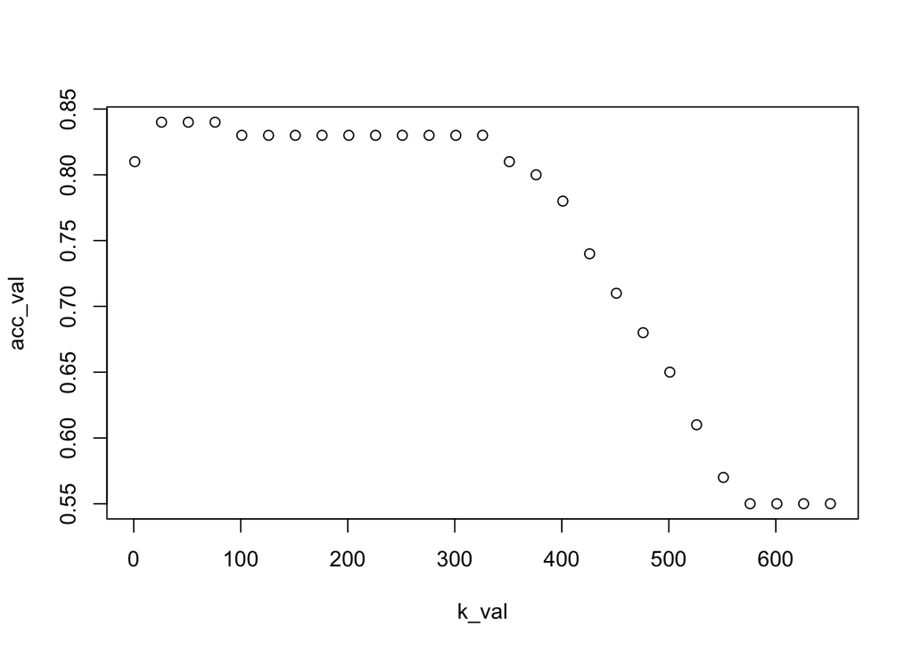

```r
# Rectangular(unweighted) kernel as optimised
knn_pred <- vector(mode="list",length = dim(org_cc_data)[1])
pred_table <- data.frame(k_val=numeric(0),acc_val=double(0)) #dataframe to hold accuracy with k
for (k0 in seq(1,nrow(org_cc_data),by=25)){ #To loop over k values
  for (i in 1:nrow(org_cc_data)){ #To loop over indvidual data points
    knn_model_v0<-kknn(R1~.,train = org_cc_data[-i,],test = org_cc_data[i,],k=k0,kernel="rectangular",scale = TRUE)
    knn_pred[i]<-as.integer(round(fitted(knn_model_v0),digits = 0)==org_cc_data$R1[i]) #majority voting > 0.5
  }
  percent_accuracy<-round(as.double(sum(unlist(knn_pred)))/nrow(org_cc_data),digits =2)
  pred_table[nrow(pred_table)+1,]=c(k0,percent_accuracy)
}
plot(pred_table)
```

**#Analysis:**

The plot above shows the Accuracy on y-axis vs ‘k’ i.e number of nearest neighbours on the x-axis. As we increase k, Accuracy is mostly static and after a certain threshold (~340), it starts dropping almost linearly to 55%, where it then stabilizes. The 55% number here is intuitive since with as many nearest neighbors as the #data points, the prediction decision basically boils down to assigning the majority label in the dataset, i.e. Negative.

**At this point, we receive a correct prediction on the negative class which constitute around 55% of the overall number of data points, while the rest 45% Positive class is misclassified.**

### Optimisation over ‘k’ and probability threshold

The KNN model as compared to SVM model provides us the prediction probability of each point being in a given class which can then be transformed into predicted labels based on the threshold value. This introduces the notion of deciding an optimal threshold value that maximizes our chosen metric. A typically used metric for classification problem is the AUC value under the ROC curve.

https://en.wikipedia.org/wiki/Receiver_operating_characteristic

```r
threshold_auc
```

|  | k | threshold_val | auc_val | acc_overall | acc_1 | acc_0 |
| --- | --- | --- | --- | --- | --- | --- |
| 1 | 20 | 0.20 | 0.8441888 | 0.8348624 | 0.9425676 | 0.7458101 |
| 2 | 20 | 0.22 | 0.8441888 | 0.8348624 | 0.9425676 | 0.7458101 |
| 3 | 20 | 0.24 | 0.8441888 | 0.8348624 | 0.9425676 | 0.7458101 |
| 4 | 20 | 0.26 | 0.8553620 | 0.8470948 | 0.9425676 | 0.7681564 |
| 5 | 20 | 0.28 | 0.8553620 | 0.8470948 | 0.9425676 | 0.7681564 |
| 6 | 20 | 0.30 | 0.8567586 | 0.8486239 | 0.9425676 | 0.7709497 |
| 7 | 20 | 0.32 | 0.8567586 | 0.8486239 | 0.9425676 | 0.7709497 |
| 8 | 20 | 0.34 | 0.8567586 | 0.8486239 | 0.9425676 | 0.7709497 |
| 9 | 20 | 0.36 | 0.8558810 | 0.8486239 | 0.9324324 | 0.7793296 |
| 10 | 20 | 0.38 | 0.8558810 | 0.8486239 | 0.9324324 | 0.7793296 |

[output cut: 207 more lines]

```r
# Final step to determine the highest value of AUC for every K
final_frame<-data.frame(k=double(0), threshold_val=double(0), auc_val=double(0), acc_overall=double(0), acc_1=double(0), acc_0=double(0))
for(k_i in seq(20, 50, by=5)){
  #print(paste("Best Probability threshold for k=",k_i))
  data_i = threshold_auc[threshold_auc$k == k_i,]
  #print (data_i[which.max(data_i$auc_val),])
  final_frame[nrow(final_frame)+1, ] <- data_i[which.max(data_i$auc_val),]
}
```

```r
final_frame
```

|  | k | threshold_val | auc_val | acc_overall | acc_1 | acc_0 |
| --- | --- | --- | --- | --- | --- | --- |
| 6 | 20 | 0.30 | 0.8567586 | 0.8486239 | 0.9425676 | 0.7709497 |
| 38 | 25 | 0.32 | 0.8564661 | 0.8486239 | 0.9391892 | 0.7737430 |
| 70 | 30 | 0.34 | 0.8558810 | 0.8486239 | 0.9324324 | 0.7793296 |
| 102 | 35 | 0.36 | 0.8572777 | 0.8501529 | 0.9324324 | 0.7821229 |
| 132 | 40 | 0.34 | 0.8561736 | 0.8486239 | 0.9358108 | 0.7765363 |
| 162 | 45 | 0.32 | 0.8609486 | 0.8532110 | 0.9425676 | 0.7793296 |
| 192 | 50 | 0.30 | 0.8595519 | 0.8516820 | 0.9425676 | 0.7765363 |

**#Analysis:** From above table we are able to choose a combination of k and threshold values, so as to maximize accuracy. However, the combinations listed above exhibit very similar Accuracy ranges (overall and split by classes as well.)